# Notebook 17 – Solutions

## Getting Started

Before running this notebook, select “Session > Restart R and Clear Output” in the menu above to start a new R session. This will clear any old data sets and give us a blank slate to start with.

## Chicago Data

This notebook is intended to get you started thinking about how to work with the various Chicago Datasets. It, and in particular my posted solutions, should be helpful in your analysis.

### Load the Data

Let’s load the data that we will be looking at through the remainder of the semester. By default it loads a 10% sample of the data; you can load the full dataset by uncommenting the other code; this requires increasing the resources on RStudio Cloud.

```r
comarea <- read_sf(file.path("data", "chicago_community_areas.geojson"))
ziparea <- read_sf(file.path("data", "zip_codes.geojson"))
socio <- read_csv(file.path("data", "census_socioeconomic.csv"))
medical <- read_csv(file.path("data", "chicago_medical_examiner_cases.csv.gz"))
crimes <- read_rds(file.path("data", "chicago_crimes_2001_2020_sample.rds"))
#crimes <- bind_rows(
#  read_csv(file.path("data", "chicago_crimes_2001_2011.csv.gz")),
#  read_csv(file.path("data", "chicago_crimes_2012_2020.csv.gz"))
#)
schools <- read_sf(file.path("data", "chicago_schools.geojson"))
police <- read_sf(file.path("data", "chicago_police_stations.geojson"))
```

This time, we will look into the temporal components of the data and see how they can be integrated into the spatial visualisations.

## Exploring the Corpus

### Univariate Exploration

Let’s start with a few simple things to try to understand the data. Produce a table showing the number of crimes associated with each `primary_type`. Sort the data from most common to least common. Take a moment to look at the types.

```r
crimes %>%
  group_by(primary_type) %>%
  summarize(sm_count()) %>%
  arrange(desc(count))
```

```
## # A tibble: 34 x 2
##    primary_type         count
##    <chr>                <int>
##  1 THEFT               137758
##  2 BATTERY             119608
##  3 CRIMINAL DAMAGE      74558
##  4 NARCOTICS            65958
##  5 ASSAULT              41439
##  6 OTHER OFFENSE        40423
##  7 BURGLARY             37106
##  8 MOTOR VEHICLE THEFT  29904
##  9 DECEPTIVE PRACTICE   26111
## 10 ROBBERY              24614
## # … with 24 more rows
```

Repeat with the `description` variable. Notice that there are far more categories here.

```r
crimes %>%
  group_by(description) %>%
  summarize(sm_count()) %>%
  arrange(desc(count))
```

```
## # A tibble: 456 x 2
##    description                  count
##    <chr>                        <int>
##  1 SIMPLE                       71810
##  2 DOMESTIC BATTERY SIMPLE      55608
##  3 $500 AND UNDER               50341
##  4 TO VEHICLE                   35688
##  5 TO PROPERTY                  34379
##  6 OVER $500                    32855
##  7 POSS: CANNABIS 30GMS OR LESS 25673
##  8 FORCIBLE ENTRY               24887
##  9 FROM BUILDING                23942
## 10 AUTOMOBILE                   23637
## # … with 446 more rows
```

And again with `location_desc`:

```r
crimes %>%
  group_by(location_desc) %>%
  summarize(sm_count()) %>%
  arrange(desc(count))
```

```
## # A tibble: 168 x 2
##    location_desc                   count
##    <chr>                           <int>
##  1 STREET                         166957
##  2 RESIDENCE                      107838
##  3 APARTMENT                       71880
##  4 SIDEWALK                        65797
##  5 OTHER                           23987
##  6 PARKING LOT/GARAGE(NON.RESID.)  18073
##  7 ALLEY                           14597
##  8 SCHOOL, PUBLIC, BUILDING        13089
##  9 RESIDENCE-GARAGE                12320
## 10 SMALL RETAIL STORE              12132
## # … with 158 more rows
```

### Spatial Analysis

Now, let’s put a few variables together. Create a plot of the community areas showing the number of crimes per person (perhaps per 1000 people). Note that you should not try to directly merge the spatial data into the crimes. This is too large and will crash R.

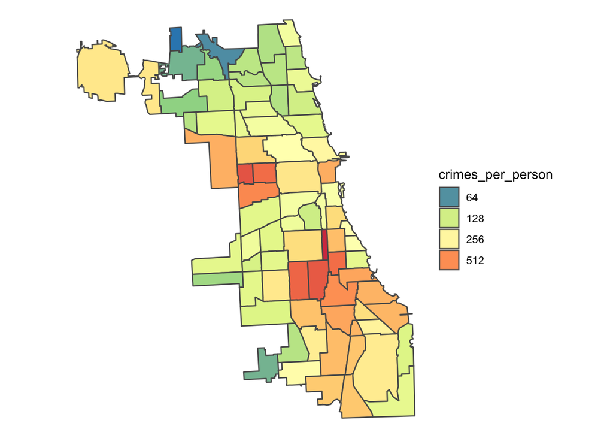

```r
crimes %>%
  group_by(comarea) %>%
  summarize(sm_count()) %>%
  inner_join(comarea, by = "comarea") %>%
  inner_join(socio, by = "comarea") %>%
  mutate(crimes_per_person = count / population * 1000) %>%
  st_as_sf() %>%
  st_transform(3436) %>%
  ggplot() +
    geom_sf(aes(fill = crimes_per_person)) +
    scale_fill_distiller(
      trans = "log2", palette = "Spectral", guide = "legend", n.breaks = 10
    ) +
    theme_void()
```

Repeat the question above with crimes per household. Notice if there are any large differences (in general, you can use either normalization, depending on your preference).

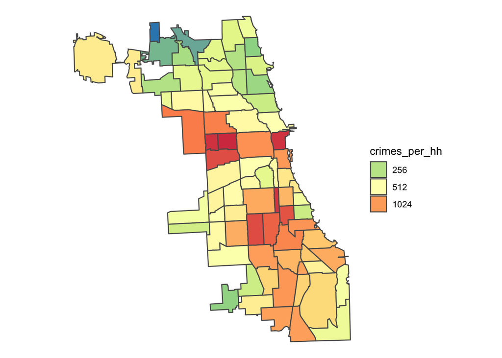

```r
crimes %>%
  group_by(comarea) %>%
  summarize(sm_count()) %>%
  inner_join(comarea, by = "comarea") %>%
  inner_join(socio, by = "comarea") %>%
  mutate(crimes_per_hh = count / num_households * 1000) %>%
  st_as_sf() %>%
  st_transform(3436) %>%
  ggplot() +
    geom_sf(aes(fill = crimes_per_hh)) +
    scale_fill_distiller(
      trans = "log2", palette = "Spectral", guide = "legend", n.breaks = 10
    ) +
    theme_void()
```

### Time

Let’s see the overall pattern of crimes over time. Summarize the dataset to show the number of crimes for each combination of year and month. Then, draw a line plot with month on the x-axis, count on the y-axis, and add `facet_wrap(~year)` to show the difference over year. Look at the plot and take note of any filtering you might want to do before doing an future analysis.

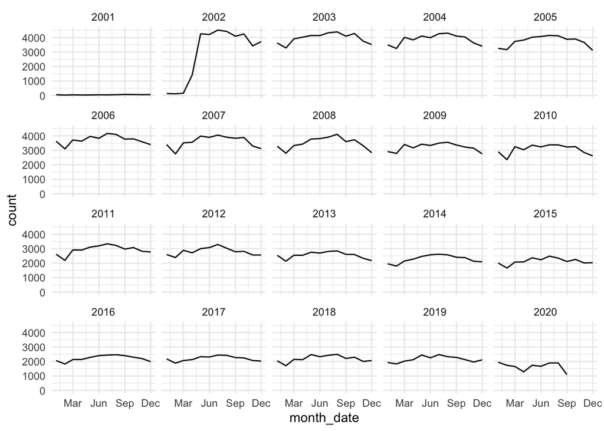

```r
crimes %>%
  mutate(year = year(date_iso), month = month(date_iso)) %>%
  group_by(year, month) %>%
  summarize(sm_count()) %>%
  mutate(month_date = make_date(month = month)) %>%
  ggplot(aes(month_date, count)) +
    geom_line() +
    scale_x_date(date_breaks = "3 month", date_labels = "%b") +
    facet_wrap(~year)
```

Now, show a line plot giving the number of crimes that occur by the hour of the day. Do not separate by year. Notice any spikes in the data.

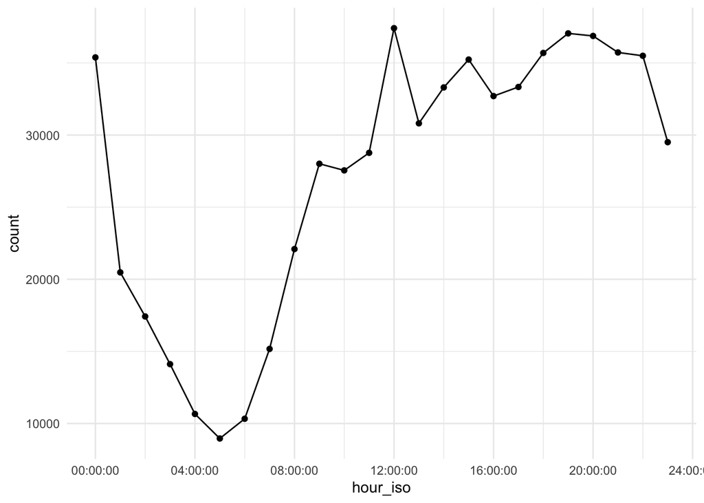

```r
crimes %>%
  mutate(hour_iso = floor_date(date_iso, "1 hour")) %>%
  mutate(hour_iso = as_hms(hour_iso)) %>%
  group_by(hour_iso) %>%
  summarize(sm_count()) %>%
  ggplot(aes(hour_iso, count)) +
    geom_line() +
    geom_point()
```

Repeat the previous question, but count the data in buckets of 15 minutes. What’s going on in this plot? Do you see any outliers or strange patterns?

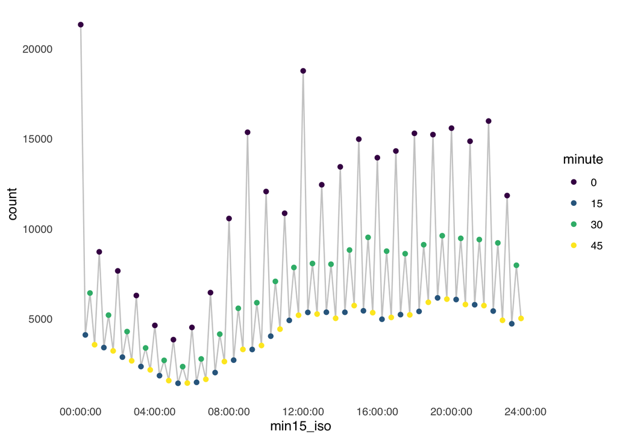

```r
crimes %>%
  mutate(min15_iso = floor_date(date_iso, "15 minutes")) %>%
  mutate(min15_iso = as_hms(min15_iso)) %>%
  group_by(min15_iso) %>%
  summarize(sm_count()) %>%
  mutate(minute = factor(minute(min15_iso))) %>%
  ggplot(aes(min15_iso, count)) +
    geom_line(color = "grey80") +
    geom_point(aes(color = minute)) +
    scale_color_viridis_d() +
    theme_sm()
```

### Multivariate Analysis

Show a scatter plot with one point for each community area, with the percentage of households below the poverty line (`hh_poverty`) on the x-axis and the number of crimes that occurred per person between 2003 and 2019 (inclusive) on the y-axis.

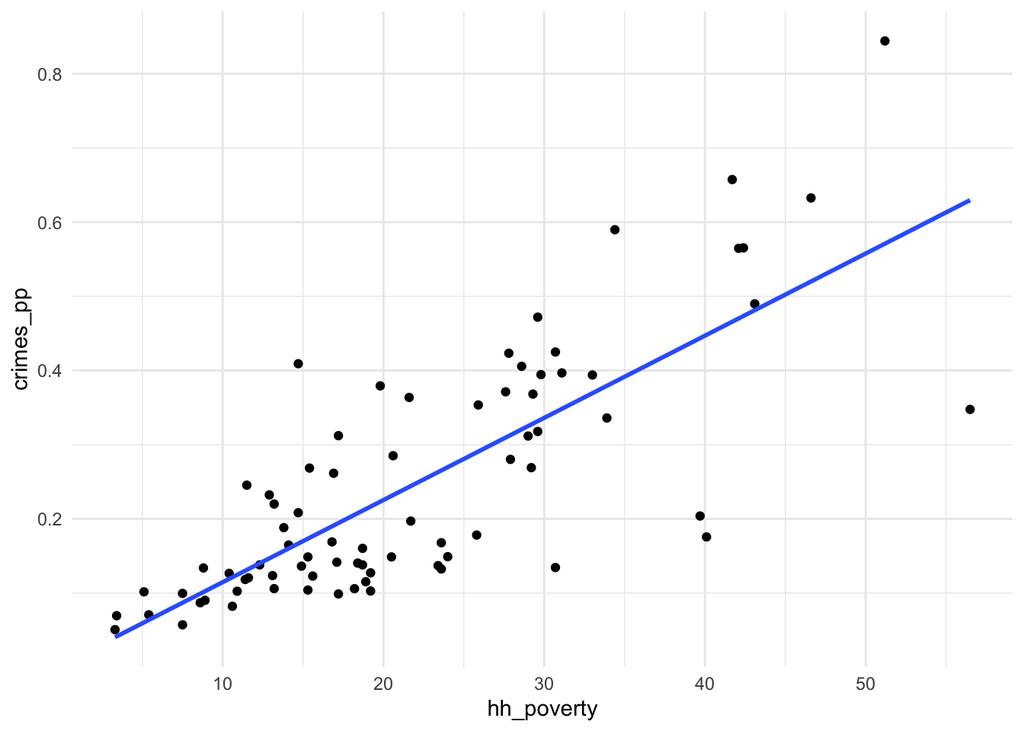

```r
crimes %>%
  filter(between(year(date_iso), 2003, 2019)) %>%
  group_by(comarea) %>%
  summarize(sm_count()) %>%
  inner_join(socio, by = "comarea") %>%
  mutate(crimes_pp = count / population) %>%
  ggplot(aes(hh_poverty, crimes_pp)) +
    geom_point() +
    geom_smooth(method = "lm", se = FALSE)
```

Create a dataset showing the percentage of crimes that result in an arrest. Note: It is best to do this using a call to `pivot_wider`.

```r
crimes %>%
  group_by(comarea, arrest) %>%
  summarize(sm_count()) %>%
  pivot_wider(values_from = count, names_from = arrest, names_prefix = "arrest_") %>%
  mutate(percentage = 100 * arrest_TRUE / (arrest_TRUE + arrest_FALSE))
```

```
## # A tibble: 78 x 4
## # Groups:   comarea [78]
##    comarea arrest_FALSE arrest_TRUE percentage
##      <dbl>        <int>       <int>      <dbl>
##  1       0           12          NA       NA
##  2       1         7271        2807       27.9
##  3       2         6761        1384       17.0
##  4       3         6494        2968       31.4
##  5       4         3813         895       19.0
##  6       5         3200         692       17.8
##  7       6        10349        2465       19.2
##  8       7         8730        1456       14.3
##  9       8        16456        5951       26.6
## 10       9          558          74       11.7
## # … with 68 more rows
```

Starting with the data you created above, plot the percentage of crimes that result in an arrest for each community area.

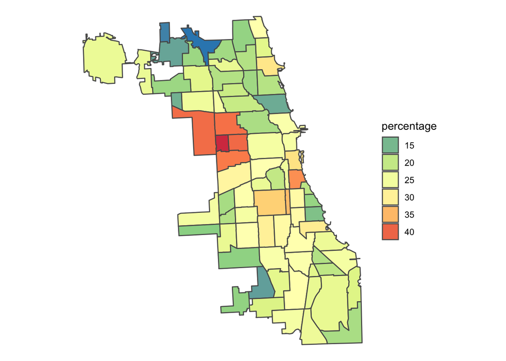

```r
crimes %>%
  group_by(comarea, arrest) %>%
  summarize(sm_count()) %>%
  pivot_wider(values_from = count, names_from = arrest, names_prefix = "arrest_") %>%
  mutate(percentage = 100 * arrest_TRUE / (arrest_TRUE + arrest_FALSE)) %>%
  inner_join(comarea, by = "comarea") %>%
  st_as_sf() %>%
  st_transform(3436) %>%
  ggplot() +
    geom_sf(aes(fill = percentage)) +
    scale_fill_distiller(
      palette = "Spectral", guide = "legend", n.breaks = 10
    ) +
    theme_void()
```

Finally, show the percentage of crimes that result in an arrest that occur during each hour of the day.

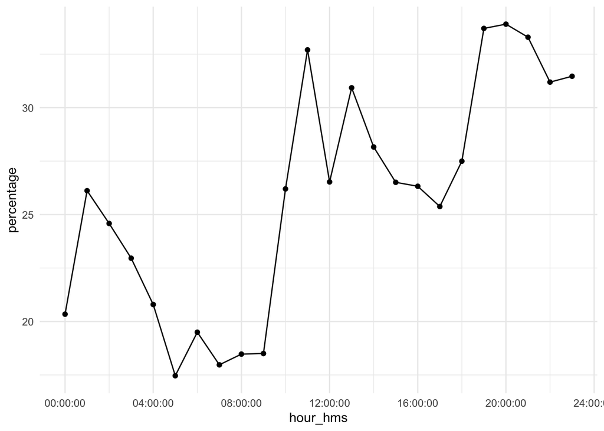

```r
crimes %>%
  mutate(hour = hour(date_iso)) %>%
  group_by(hour, arrest) %>%
  summarize(sm_count()) %>%
  pivot_wider(values_from = count, names_from = arrest, names_prefix = "arrest_") %>%
  mutate(percentage = 100 * arrest_TRUE / (arrest_TRUE + arrest_FALSE)) %>%
  mutate(hour_hms = hms(hour = hour)) %>%
  ggplot(aes(hour_hms, percentage)) +
    geom_point() +
    geom_line()
```

### Multivariate by Area

Let’s try to replicate the previous plot, but split the data into two groups. One group will consist of data from “Rogers Park” (area 1); the other group will come from the rest of the city. Your plot should now have two lines to show the pattern for these two regions.

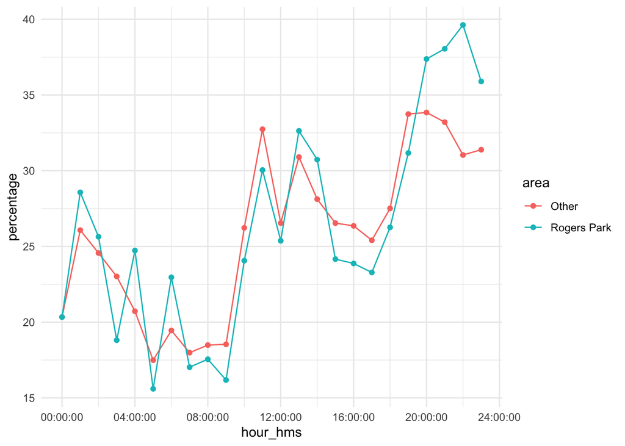

```r
crimes %>%
  mutate(hour = hour(date_iso)) %>%
  mutate(area = if_else(comarea == 1, "Rogers Park", "Other")) %>%
  group_by(hour, area, arrest) %>%
  summarize(sm_count()) %>%
  pivot_wider(values_from = count, names_from = arrest, names_prefix = "arrest_") %>%
  mutate(percentage = 100 * arrest_TRUE / (arrest_TRUE + arrest_FALSE)) %>%
  mutate(hour_hms = hms(hour = hour)) %>%
  ggplot(aes(hour_hms, percentage)) +
    geom_point(aes(color = area)) +
    geom_line(aes(color = area))
```

And then repeat the same plot, but show the arrest rate pattern for these two regions (Rogers Park vs. the rest of the city) by year.

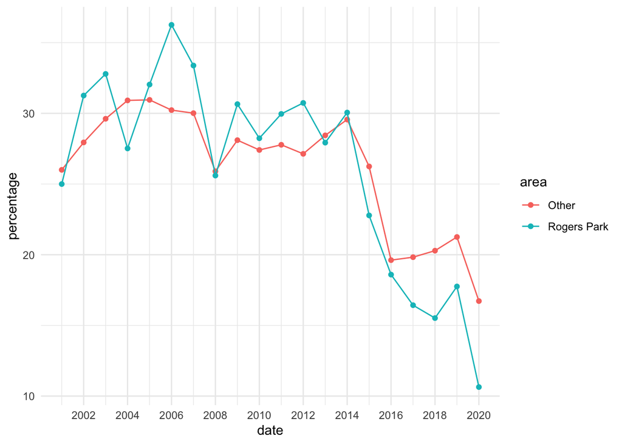

```r
crimes %>%
  mutate(year = year(date_iso)) %>%
  mutate(area = if_else(comarea == 1, "Rogers Park", "Other")) %>%
  group_by(year, area, arrest) %>%
  summarize(sm_count()) %>%
  pivot_wider(values_from = count, names_from = arrest, names_prefix = "arrest_") %>%
  mutate(percentage = 100 * arrest_TRUE / (arrest_TRUE + arrest_FALSE)) %>%
  mutate(date = make_date(year = year)) %>%
  ggplot(aes(date, percentage)) +
    geom_point(aes(color = area)) +
    geom_line(aes(color = area)) +
    scale_x_date(date_breaks = "2 year", date_labels = "%Y")
```

### Notes for Above

I tried to give a good idea of some of the things you can do and look at with the Chicago dataset here. By changing the thing you are looking at the percentage of (percent domestic, percent in a particular location, percent with a particular description) you should be able to find several interesting patterns. You can also filter the data further before looking at the split. For example, only including one type of crime, or first filtering out a region of interest and seeing how crimes changed from 2019 to 2020. We did not do this above, but you can also see the seasonal differences in addition to time of day and year-over-year.